# Biophysics of short term plasticity

### Roberto García Medina$^1$, Marco Arieli Herrera-Valdez$^1$

#### $^1$ Laboratorio de Fisiología de Sistemas, Facultad de Ciencias, Universidad Nacional Autónoma de México

Let $c$ represent the calcium concentration in the presynaptic terminal. Assume that \begin{eqnarray} \partial_t c &=& \frac{c_{\infty}-c}{\tau_c} + c_{in} ,\quad \textrm{presynaptic calcium concentration} \\ \partial_t r &=& \alpha_c c^n (1-r) - \beta_c r = \frac{r_{\infty}(c)-r}{\tau_r(c)},\quad \textrm{activation of release machinery by calcium} \\ \partial_t q &=& \frac{q_{\infty}-q}{\tau_q} + \delta q r,\quad \textrm{normalized number of quanta in readily releasable pool} \end{eqnarray} The parameters $c_{\infty}$ and $q_{\infty}$ represent the steady state concentration of calcium in the presynaptic terminal and the quanta in the readily releasable pool normalized by its maximum, respectively. The parameters $\tau_c$ and $\tau_q$ represent the time constants for the recovery of the presynaptic calcium concentration and the refilling of vesicles in the readily releasable pool.

The normalized quanta of neurotransmitter released is $rq$.

Assume the activation of calcium dependent proteins in the presynaptic release machinery is instantaneous. That is, $r=r_{\infty}(c)$. Then the system reduces to \begin{eqnarray} \partial_t c &=& \frac{c_{\infty}-c}{\tau_c} + c_{in}, \\ \partial_t q &=& \frac{q_{\infty}-q}{\tau_q} + \delta q r_{\infty}(c). \end{eqnarray}

```python
import scipy as sc
import matplotlib.pylab as gr
```

```python
def Hill(u,c,n=2):
    uu = u**n
    return uu/(uu+ c**n)

def RK2_Autonomous(f,pars, eParNames=[], eParList=[]):
    """Second-order Runge-Kutta method to solve x' = f(x,t) with U(t[0]) = U0.
    NOTES:
        This version is based on the algorithm presented in "Numerical
        Analysis", 6th Edition, by Burden and Faires, Brooks-Cole, 1997.
    """
    U=sc.zeros((pars['nSteps'], sc.prod(sc.shape(pars['ic']))),"float64")
    U[0]=pars['ic']
    for i in range(pars['nSteps']-1):
        for k in range(len(eParNames)):
            pars[eParNames[k]]= eParList[k][i]
        #t = stepSize * i
        k1 = pars['stepSize'] * f( U[i], pars) / 2.0
        U[i+1] = U[i] + pars['stepSize'] * f( U[i] + k1, pars)
    return U.transpose()
```

```python
cPre={'c_PreInfty_muM':0.0001,'tau_c_Pre':50.0,'c_conv':0.0001,'c_halfAct_r_muM':0.5}
rPre={'alpha_r':2.0,'c_coop_r':4.0}
qPre={'q_Infty':1.0,'tau_q':25.0}
p=dict(); p.update(cPre);p.update(rPre);p.update(qPre)
print(p)
```

```
{'tau_c_Pre': 50.0, 'alpha_r': 2.0, 'c_coop_r': 4.0, 'q_Infty': 1.0, 'c_halfAct_r_muM': 0.5, 'c_PreInfty_muM': 0.0001, 'c_conv': 0.0001, 'tau_q': 25.0}
```

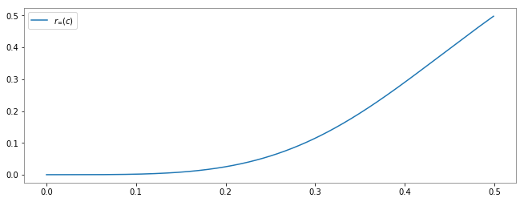

```python
gr.figure(figsize=(11,4))
c = sc.arange(0,0.5,0.001)
rSS = Hill(c,p['c_halfAct_r_muM'],p['c_coop_r'])
gr.plot(c,rSS,label='$r_{\infty}(c)$')
gr.legend()
```

```python
def presynSTSP(U,p):
    c,r,q= U
    rSS = Hill(c,p['c_halfAct_r_muM'],p['c_coop_r'])
    tau_r = rSS/p['alpha_r']
    dc = (p['c_PreInfty_muM'] - c)/p['tau_c_Pre'] + p['c_PreIn']/p['stepSize']
    dr = (rSS-r)/tau_r
    dq = (p['q_Infty']-q)/p['tau_q'] - r*q/p['stepSize']
    return sc.array([dc,dr,dq])

def presynSTSP_2D(U,p):
    c,q= U
    rSS = Hill(c,p['c_halfAct_r_muM'],p['c_coop_r'])
    dc = (p['c_PreInfty_muM'] - c)/p['tau_c_Pre'] + p['c_PreIn']/p['stepSize']
    dq = (p['q_Infty']-q)/p['tau_q'] - rSS*q/p['stepSize']
    return sc.array([dc,dq])
```

```python
p['tMax'] = 500.0; p['stepSize'] = 1/80.0;
p['sampTimes']= sc.arange(0,p['tMax'],p['stepSize'])
p['nSteps']= sc.int32(p['tMax']/p['stepSize'])
#
pulsePeriod = 50.0; pulseStart=50.0; nPulses=5
pulseTimes= pulseStart + sc.arange(0,(nPulses+1)*pulsePeriod,pulsePeriod)
pulseInds = sc.int32(pulseTimes/p['stepSize']);
#
```

## Dynamics in the 2D model

```python
# Function to plot the 2D dynamics
def solve2DDynamics(p):
    p['ic'] = sc.array([0.0001,p['q_Infty']]);
    c2,q2=RK2_Autonomous(f=presynSTSP_2D,pars=p, eParNames=['c_PreIn'], eParList=[c_PreIn])
    f1=gr.figure(figsize=(13,7)); rows=3; cols=1; ax=list()
    ax=[f1.add_subplot(rows,cols,n+1) for n in range(rows*cols)]
    rSS2 = Hill(c2,p['c_halfAct_r_muM'],p['c_coop_r'])
    ax[0].plot(p['sampTimes'],c2,'orange',label='$c(t)$')
    ax[0].plot(p['sampTimes'],rSS2,'b',lw=3,alpha=0.4,label='$r_{\infty}(c)$')
    ax[1].plot(p['sampTimes'],q2,'k',label='$q(t)$')
    ax[2].plot(p['sampTimes'],q2*rSS2,'k',label='$r_{\infty}(c)q(t)$')
    [ax[n].legend() for n in range(rows*cols)]
    return c2,rSS2,q2
```

### Facilitation

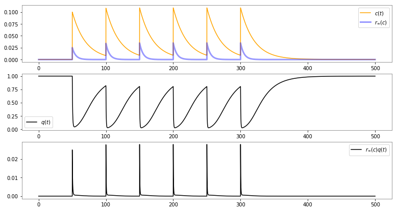

```python
c_PreIn = sc.zeros(p['nSteps']);  c_PreIn[pulseInds]=0.1
p['c_halfAct_r_muM']=0.25; p['tau_c_Pre']=20.0; p['tau_q']=20.0; p['c_PreIn']=0.0
c2,q2,rSS2= solve2DDynamics(p)
```

### Depression

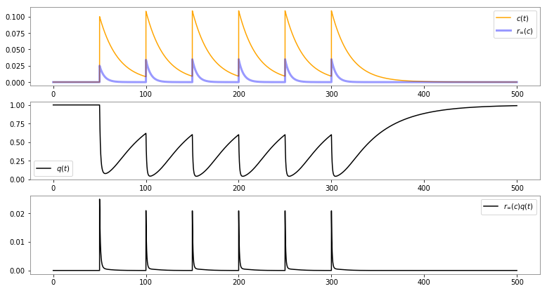

```python
c_PreIn = sc.zeros(p['nSteps']);  c_PreIn[pulseInds]=0.1
p['c_halfAct_r_muM']=0.25; p['tau_c_Pre']=20.0; p['tau_q']=40.0; p['c_PreIn']=0.0
c2,q2,rSS2= solve2DDynamics(p)
```

### Biphasic up

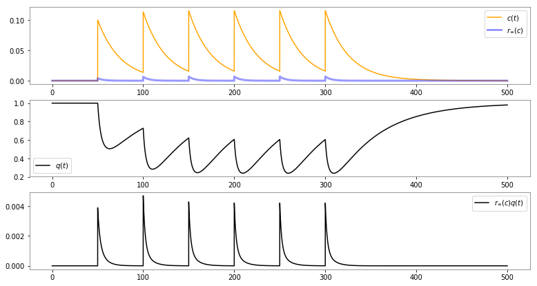

```python
c_PreIn = sc.zeros(p['nSteps']);  c_PreIn[pulseInds]=0.1
p['c_halfAct_r_muM']=0.4; p['tau_c_Pre']=25.0; p['tau_q']=50.0; p['c_PreIn']=0.0
c2,q2,rSS2= solve2DDynamics(p)
```

## Dynamics in the 3D model

```python
# Function to plot the 3D dynamics
def solve3DDynamics(p):
    c,r,q=RK2_Autonomous(f=presynSTSP,pars=p, eParNames=['c_PreIn'], eParList=[c_PreIn])
    #
    f1=gr.figure(figsize=(13,7)); rows=3; cols=1; ax=list()
    ax=[f1.add_subplot(rows,cols,n+1) for n in range(rows*cols)]
    rSS = Hill(c,p['c_halfAct_r_muM'],p['c_coop_r'])
    ax[0].plot(p['sampTimes'],c,'orange',label='$c(t)$')
    ax[0].plot(p['sampTimes'],r,'b',lw=1,alpha=0.99,label='$r(t)$')
    ax[0].plot(p['sampTimes'],rSS,'b',lw=3,alpha=0.4,label='$r_{\infty}(c)$')
    ax[1].plot(p['sampTimes'],q,'k',label='$q(t)$')
    ax[2].plot(p['sampTimes'],q*rSS,'k',lw=3, alpha=0.3, label='$r_{\infty}(c)q(t)$')
    ax[2].plot(p['sampTimes'],q*r,'k', lw=1, label='$r_{\infty}(c)q(t)$')
    [ax[n].legend() for n in range(rows*cols)]
    return c,r,q
```

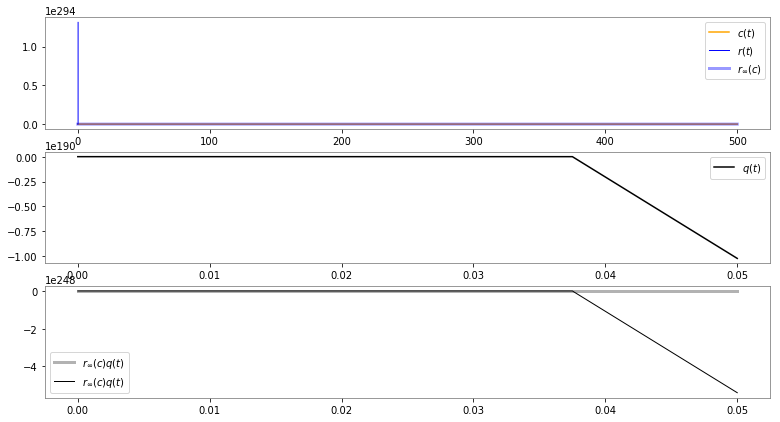

```python
c_PreIn = sc.zeros(p['nSteps']);  c_PreIn[pulseInds]=0.3
p['c_halfAct_r_muM']=0.25; p['tau_c_Pre']=50.0; p['tau_q']=20.0; p['c_PreIn']=0.0
#
p['ic'] = sc.array([0.001,0.0001, p['q_Infty']]);
#
c,r,q=solve3DDynamics(p)
```